# act_report

## Report: act_report

This report conveys all of the insights and displays the visualizations generated by the wrangled data. Following the wrangling process, I stored, analyzed, and visualized the datasets.

### Storing the Dataset

I saved the wrangled dataset to a CSV file named "twitter_archive_master.csv" using `pd.to_csv()`.

### Analyzing and Visualizing Data

The following insights and visualizations were made:

### 1. The most popular dog name

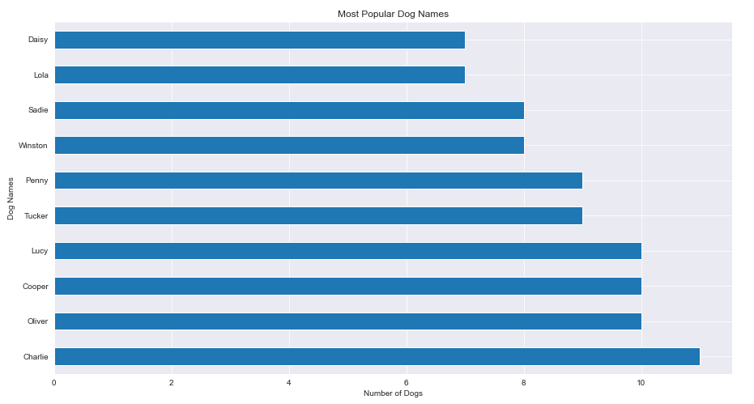

According to the above graph, Charlie was the most popular dog name, with a total of 11. With a total of 10, the names Oliver, Cooper, and Lucy were close behind.

### 2. Percentage of different Dog Stages

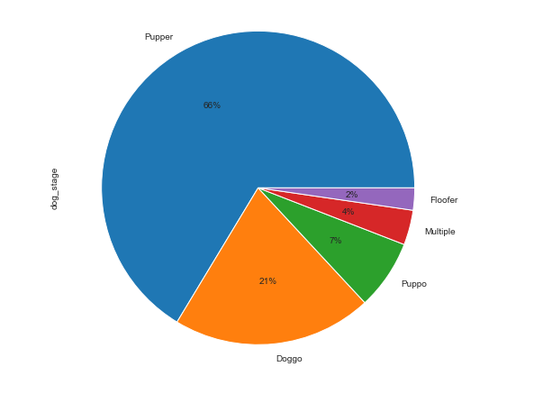

According to the pie chart, Pupper has the highest percentage among other dog stages with a share of 66%, while Floofer has the lowest percentage among other dog stages with a share of 2%.

### 3. Relationship between retweet count and favorite count

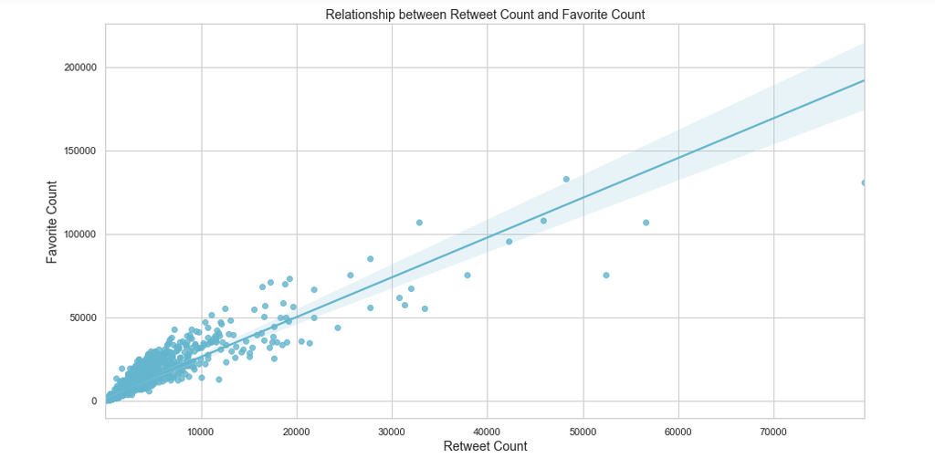

The above plot shows that the retweet count and favorite count have a positive correlation (0.91). This indicates that both parameters have a linear relationship.

### 4. Number of retweets over time

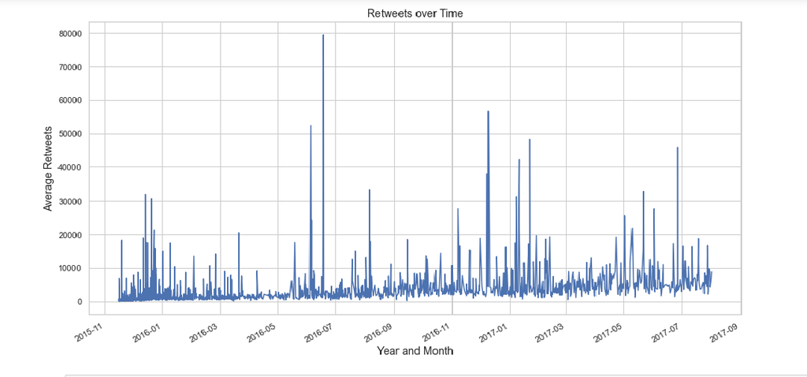